# Working with Multiple Modification Types

# Introduction

Bacterial genomes frequently carry multiple simultaneous DNA methylation marks:

- **6mA** (N6-methyladenine) — deposited by Dam methyltransferase at GATC motifs; functions in mismatch repair and cell-cycle regulation.
- **5mC** (5-methylcytosine) — deposited by Dcm methyltransferase at CCWGG motifs; roles in gene regulation are less well characterized in bacteria.
- **4mC** (N4-methylcytosine) — deposited by restriction-modification systems at various sequence motifs; protects against foreign DNA.

`comma` stores all modification types in a single `commaData` object, enabling joint analysis, comparison, and visualization across modification types.

This vignette demonstrates multi-modification workflows using the built-in `comma_example_data` dataset, which contains both 6mA and 5mC sites.

```r
library(comma)
data(comma_example_data)
```

# Exploring Multiple Modification Types

## What modifications are present?

```r
modTypes(comma_example_data)
```

```
#> [1] "5mC" "6mA"
```

## Count sites per modification type

```r
table(siteInfo(comma_example_data)$mod_type)
```

```
#>
#> 5mC 6mA
#> 100 200
```

## Per-modification methylation summary

`methylomeSummary()` reports stats per sample. Combine it with `mod_type` filtering to compare distributions:

```r
methylomeSummary(comma_example_data, mod_type = "6mA")[,
    c("sample_name", "condition", "mean_beta", "median_beta", "n_covered")]
```

```
#>   sample_name condition mean_beta median_beta n_covered
#> 1      ctrl_1   control 0.8948652   0.9097048       200
#> 2      ctrl_2   control 0.9015528   0.9192407       200
#> 3     treat_1 treatment 0.7988257   0.8923664       200
```

```r
methylomeSummary(comma_example_data, mod_type = "5mC")[,
    c("sample_name", "condition", "mean_beta", "median_beta", "n_covered")]
```

```
#>   sample_name condition mean_beta median_beta n_covered
#> 1      ctrl_1   control 0.8029502   0.8306475       100
#> 2      ctrl_2   control 0.7795787   0.8032102       100
#> 3     treat_1 treatment 0.8220365   0.8539660       100
```

# Distribution Comparison Across Modification Types

`plot_methylation_distribution()` automatically facets by modification type when multiple types are present:

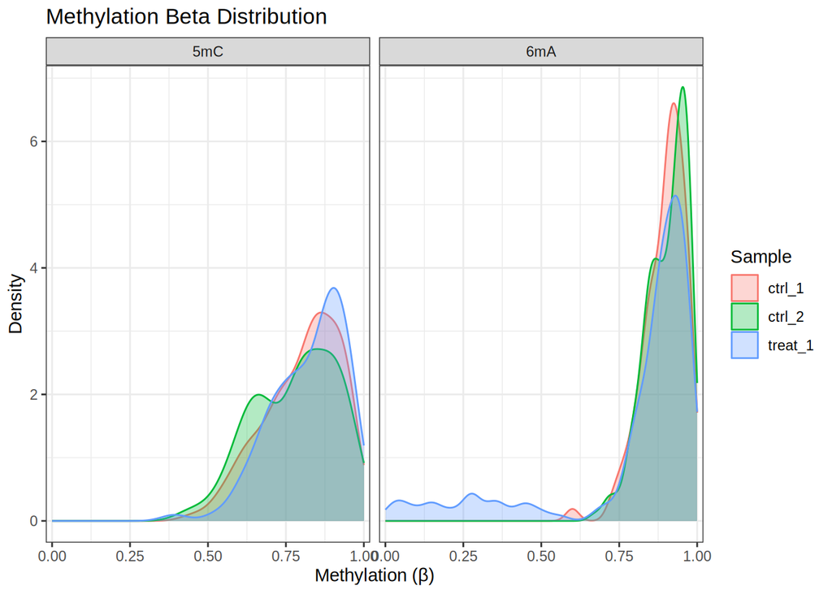

Beta value density per sample, faceted by modification type.

```r
plot_methylation_distribution(comma_example_data, per_sample = TRUE)
```

6mA sites in bacteria commonly show a bimodal distribution (near 0 or near 1) because restriction-modification systems methylate recognition sequences with high efficiency. 5mC patterns can be more variable.

# Subsetting by Modification Type

Use `subset()` to extract a single modification type:

```r
only_6ma <- subset(comma_example_data, mod_type = "6mA")
only_5mc <- subset(comma_example_data, mod_type = "5mC")

cat("6mA sites:", nrow(methylation(only_6ma)), "\n")
```

```
#> 6mA sites: 200
```

```r
cat("5mC sites:", nrow(methylation(only_5mc)), "\n")
```

```
#> 5mC sites: 100
```

# Differential Methylation: Testing Each Modification Type

## Test all types in one call

By default, `diffMethyl()` tests all modification types present in the object. Use `results(..., mod_type = "6mA")` to extract type-specific results:

```r
dm_all <- diffMethyl(comma_example_data, formula = ~ condition)
res_6ma <- results(dm_all, mod_type = "6mA")
res_5mc <- results(dm_all, mod_type = "5mC")

cat("6mA: significant sites (padj < 0.05, |Δβ| ≥ 0.2):",
    sum(!is.na(res_6ma$dm_padj) & res_6ma$dm_padj < 0.05 &
        abs(res_6ma$dm_delta_beta) >= 0.2, na.rm = TRUE), "\n")
```

```
#> 6mA: significant sites (padj < 0.05, |Δβ| ≥ 0.2): 0
```

```r
cat("5mC: significant sites (padj < 0.05, |Δβ| ≥ 0.2):",
    sum(!is.na(res_5mc$dm_padj) & res_5mc$dm_padj < 0.05 &
        abs(res_5mc$dm_delta_beta) >= 0.2, na.rm = TRUE), "\n")
```

```
#> 5mC: significant sites (padj < 0.05, |Δβ| ≥ 0.2): 0
```

## Volcano plots per modification type

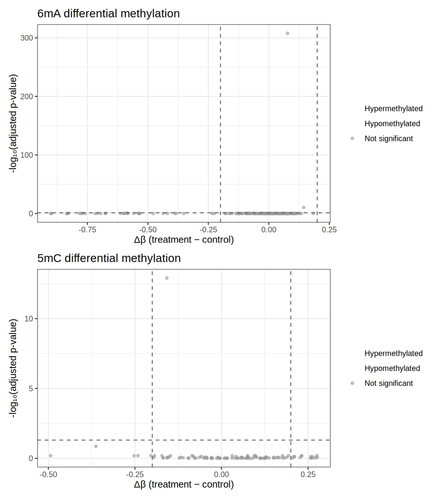

6mA differential methylation (top) and 5mC (bottom).

```r
p_6ma <- plot_volcano(res_6ma) +
    ggplot2::ggtitle("6mA differential methylation")
p_5mc <- plot_volcano(res_5mc) +
    ggplot2::ggtitle("5mC differential methylation")

# Arrange side by side if patchwork is available
if (requireNamespace("patchwork", quietly = TRUE)) {
    patchwork::wrap_plots(p_6ma, p_5mc, ncol = 1L)
} else {
    print(p_6ma)
    print(p_5mc)
}
```

# PCA Across Modification Types

The PCA plot uses all sites by default. Use `mod_type` to restrict to a single modification type:

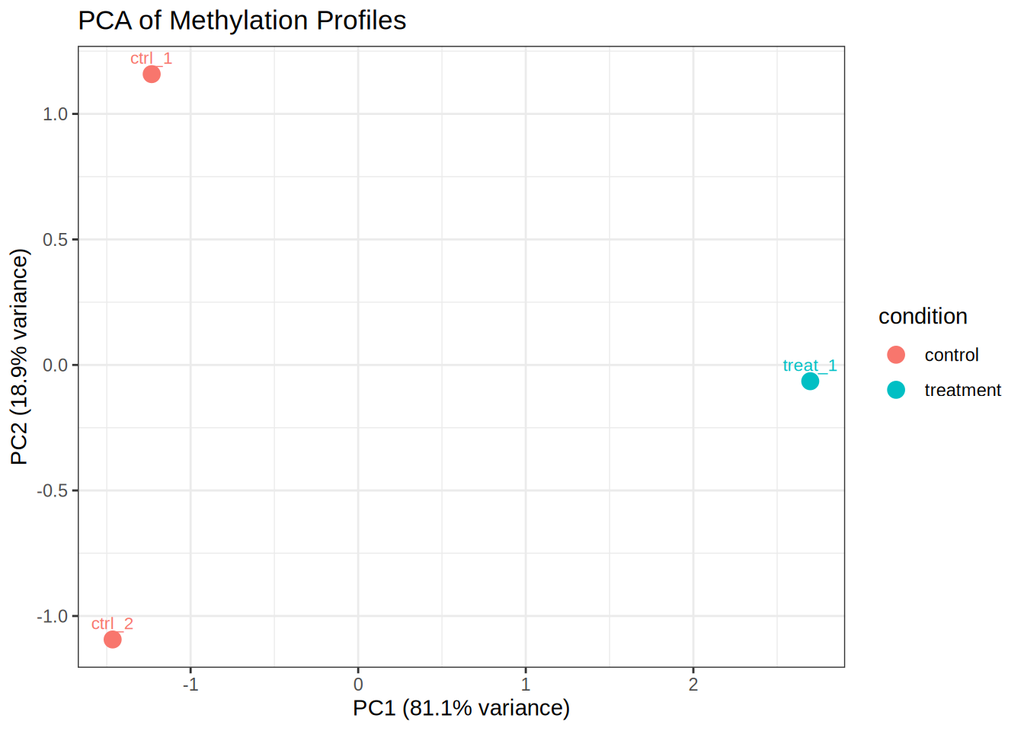

PCA using all modification types.

```r
plot_pca(comma_example_data, color_by = "condition")
```

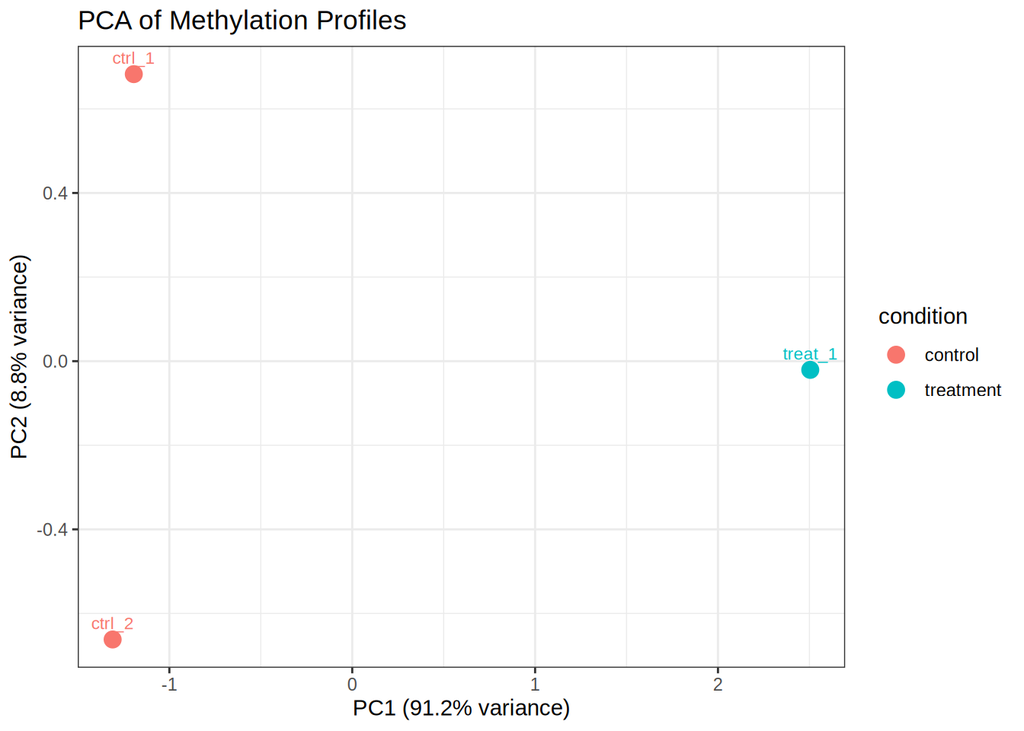

PCA using 6mA sites only.

```r
plot_pca(comma_example_data, mod_type = "6mA", color_by = "condition")
```

# Genome Track with Both Modification Types

When `mod_type = NULL`, `plot_genome_track()` displays sites from all modification types, using different colors to distinguish them:

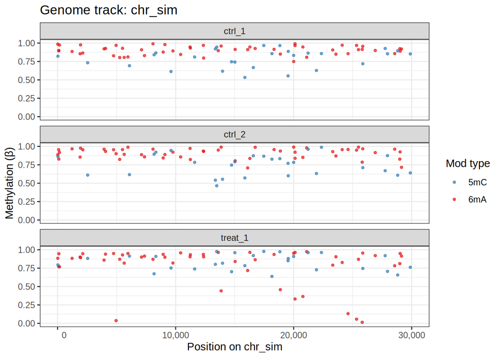

Genome track showing 6mA (red) and 5mC (blue) sites.

```r
plot_genome_track(comma_example_data, chromosome = "chr_sim",
                  start = 1L, end = 30000L, annotation = FALSE)
```

# Heatmaps per Modification Type

Filter the `results()` output to a single modification type before passing it to `plot_heatmap()`:

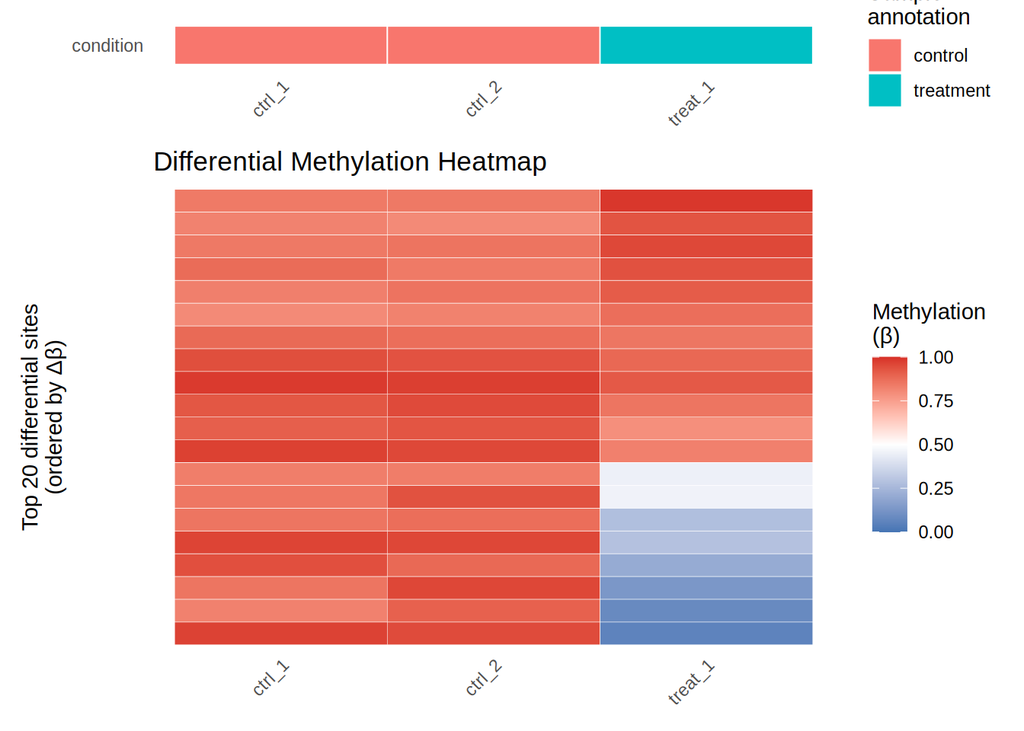

Heatmap of top 20 differentially methylated 6mA sites.

```r
plot_heatmap(res_6ma, dm_all, n_sites = 20L)
```